# 36-315 Homework 02, Spring 2019

Eu Jing Chua

Due Wednesday, Sept 11, 2019 (11:59pm ET) on Canvas

# Homework 02: Introduction to `ggplot` and 1-D Categorical Data

# Problem 1

**`R` Style Guides: Google vs. Hadley**:

1. (9 points) What are the main differences between these two style guides? Find at least 5 differences.
- Google prefers using `BigCamelCase` for function names but Hadley prefers `lower_snake_case`.
- Private functions should begin with a dot for Google
- Google prefers explicit returns
- Google does not support using right-hand assignment
- Google also does not recommend using `attach()`
2. (1 point) Specify which style guide you will be using in this assignment.

I will be using Hadley Wickham’s style guide.

# Problem 2

**Critiquing Graphs**:

1. (5 points) **Include the graph in your assignment**. Two choices here:

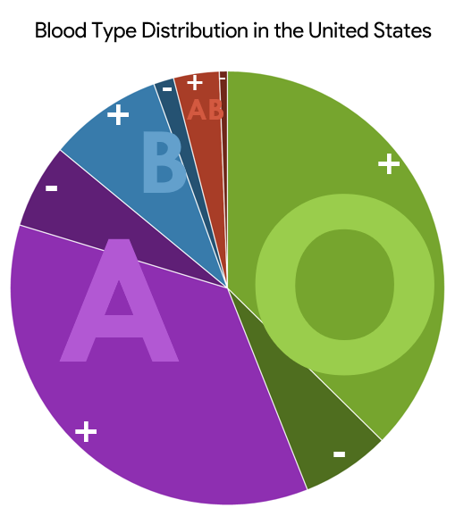

2. (5 points) **Describe the graph**.

The graph shows the proportion of each blood type in the US as a pie-chart. The big labels indicate the general blood type letter (A, B, AB, O) while the light and dark shading incidates the +/- of the blood type. The main thing we can infer is that A+ and O+ dominates the proportions.

3. (5 points) **Critique the graph**.

The graph achieves its goal of showing the relative proportions of each blood type in the US. It is very minimalistic in that there is no unnecessary amount of data ink. However, there are no numerical labels anywhere so we do not know the actual proportions, if the area of each part of the pie-chart is proportional to the actual proportion. The attempt at overlaping the blood type letter over two regions and using color shades to differentiate the + and - succintly labels the regions, but is abit too vague and requires additional interpretation. A color map, showing the mapping between actual colors and blood types, would help with this. Also, I would label the actual numerical proportions so relative comparisons will be even easier and more accurate.

4. (5 points) **Critique the caption and/or surrounding text**.

There is no surrounding text and captions, besides the main title itself. The title is quite informative for this simple dataset and nothing much else is needed. If anything, I think including some simple information about which blood types can transfer to which others will provide even more insight about what the distribution says about the state of blood transfusions in the US.

# Problem 3

**Bar Charts**:

1. (1 point) Load the Titanic data from Lab 02. How many rows does the dataset have? How many columns does the dataset have? Make sure that the variable `Pclass` is correctly recognized as `factor` variable by running `titanic <- mutate(titanic, Pclass = factor(Pclass))` if necessary. Is this an ordered variable?

```r
library(tidyverse)

#  Load the data into R
titanic <- read_csv("https://raw.githubusercontent.com/mateyneykov/315_code_data/master/data/titanic.csv")
titanic <- mutate(titanic, Pclass = factor(Pclass))

dim(titanic)
```

```
## [1] 712  12
```

There are 712 rows and 12 columns. `Pclass` is not ordered as it represents the ticket class, which has no inherent ordering (assume in this case).

2. (5 points) Create a bar chart of the `Pclass` variable. Be that your axes are properly labeled, and that the graph has a proper title. Make sure that each bar in the graph has the same color. To do this, use `+ geom_bar(fill = "pink", color = "black")`. Change the `fill` and `color` commands. What do each of them do?

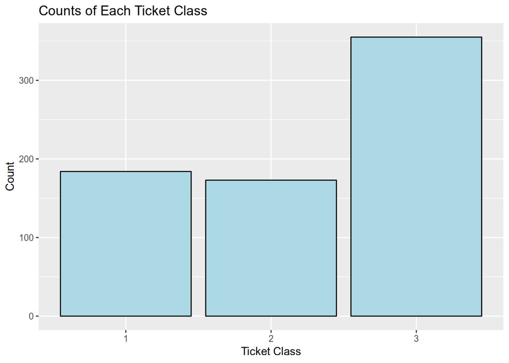

```r
ggplot(titanic, aes(x = Pclass)) +
    geom_bar(fill = "lightblue", color = "black") +
    labs(title = "Counts of Each Ticket Class",
         x = "Ticket Class",
         y = "Count")
```

The `fill` changes the colors of the bars itself, and `color` changes the color of the outline.

3. (4 points) You can also specify HEX color values when choosing a color, e.g. `fill = "#4169E1"`. Use a website like [this one](http://www.w3schools.com/colors/colors_picker.asp) to pick a color of your choice, and fill the bars with that color (and display the updated graphic below).

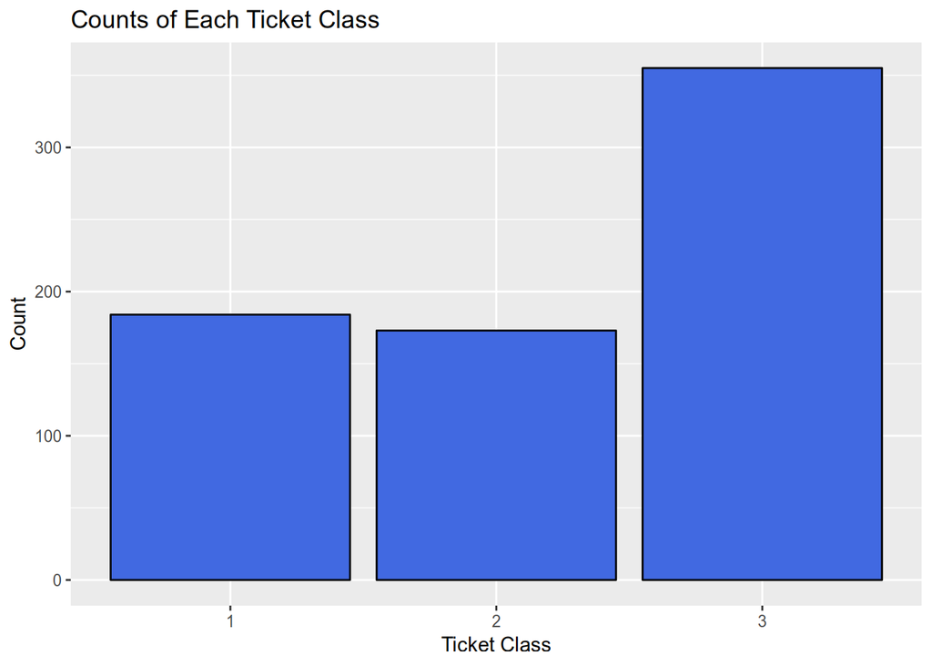

```r
ggplot(titanic, aes(x = Pclass)) +
    geom_bar(fill = "#4169E1", color = "black") +
    labs(title = "Counts of Each Ticket Class",
         x = "Ticket Class",
         y = "Count")
```

# Problem 4

**Spine Charts**:

1. (4 points) Re-create the graph from Problem 3, but use a spine chart. That is, use a spine chart to show the distribution of `Pclass`. Be sure to correctly label the axes – remember, their interpretation may have changed from Problem 3. Include an appropriate title (always do this).

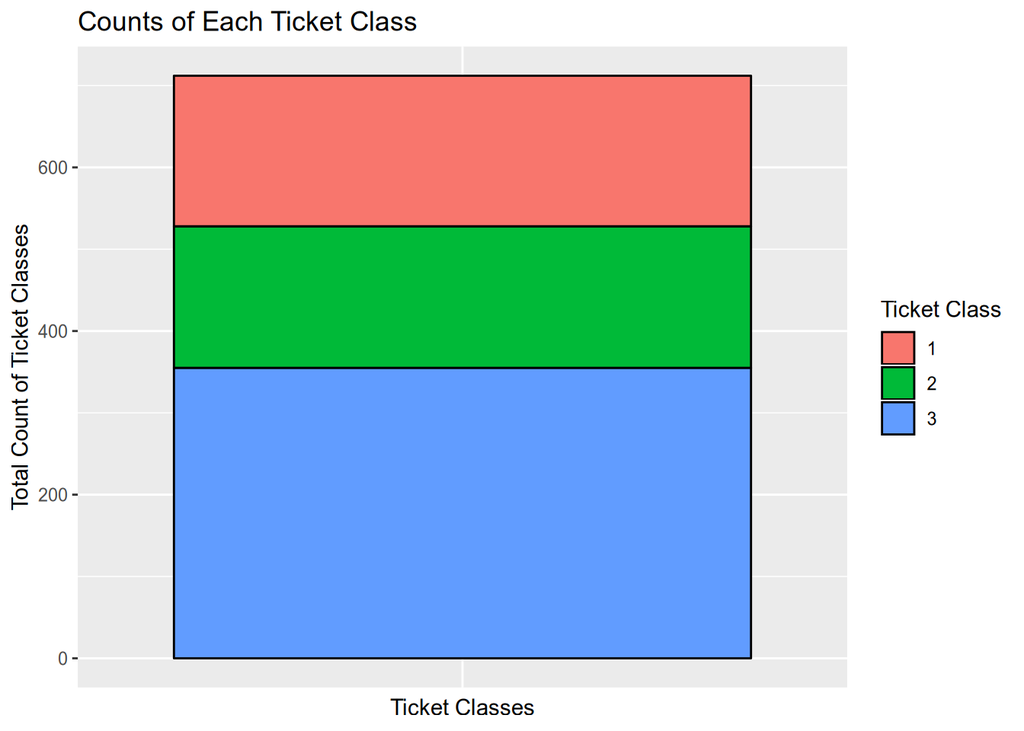

```r
ggplot(titanic, aes(x = Pclass)) +
    geom_bar(aes(x = factor(1), fill = Pclass), color = "black") +
    labs(title = "Counts of Each Ticket Class",
         fill = "Ticket Class",
         x = "Ticket Classes",
         y = "Total Count of Ticket Classes") +
    theme(axis.ticks.x = element_blank(),
          axis.text.x = element_blank())
```

2. (3 points) In a spine chart, what are the widths of the bars proportional to (if anything)? What are the heights of the bars proportional to (if anything)? How is this different from a bar chart?

In a spine chart, all widths are the same and thus are not proportional to anything in particular. The heights of each component are proportional to the counts we observe. In a bar chart, the bars are separate and the height of each bar is the one proportional to the counts we observe.

3. (3 points) `ggplot()` allows us to easily flip the orientation of our graphs without changing any of the code. To do this, you simply have to add `+ coord_flip()` to your existing code. Do this in a separate code block for the spine chart from part (a), and discuss the differences in the two plots.

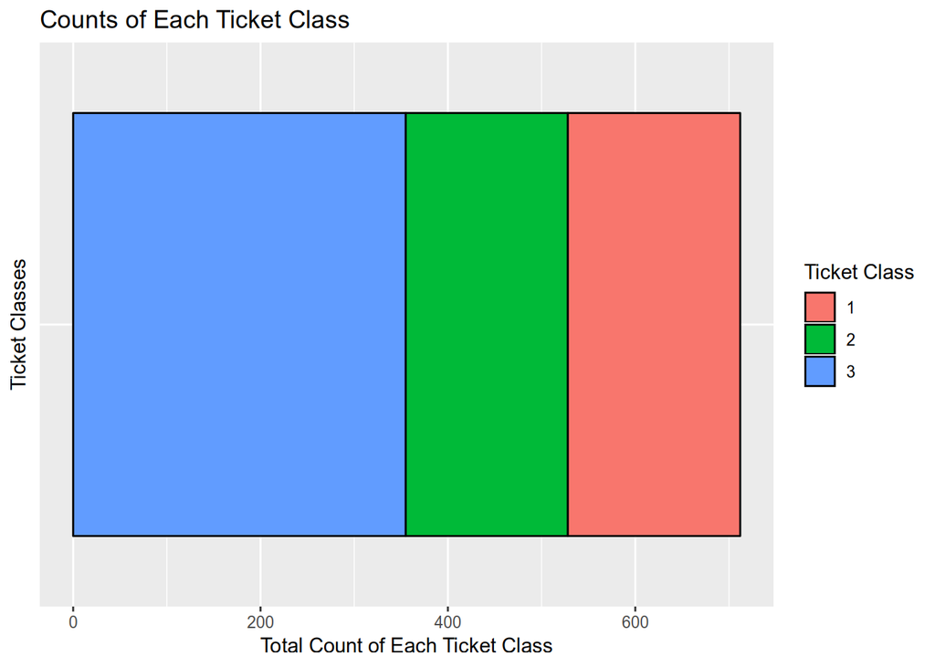

```r
ggplot(titanic, aes(x = Pclass)) +
    geom_bar(aes(x = factor(1), fill = Pclass), color = "black") +
    labs(title = "Counts of Each Ticket Class",
         fill = "Ticket Class",
         x = "Ticket Classes",
         y = "Total Count of Each Ticket Class") +
    coord_flip() +
    theme(axis.ticks.y = element_blank(),
          axis.text.y = element_blank())
```

4. (BONUS: 1 point) Remove the ugly `factor(1)` from the x-axis label, without changing the rest of the graphic.
5. (BONUS: 1 point) Remove the tick on the x-axis.

# Problem 5

**Rose Diagrams**:

1. (4 points) Re-create the graph from Problem 3, but use a rose diagram. Be sure to correctly label the axes, if necessary. Include an appropriate title.

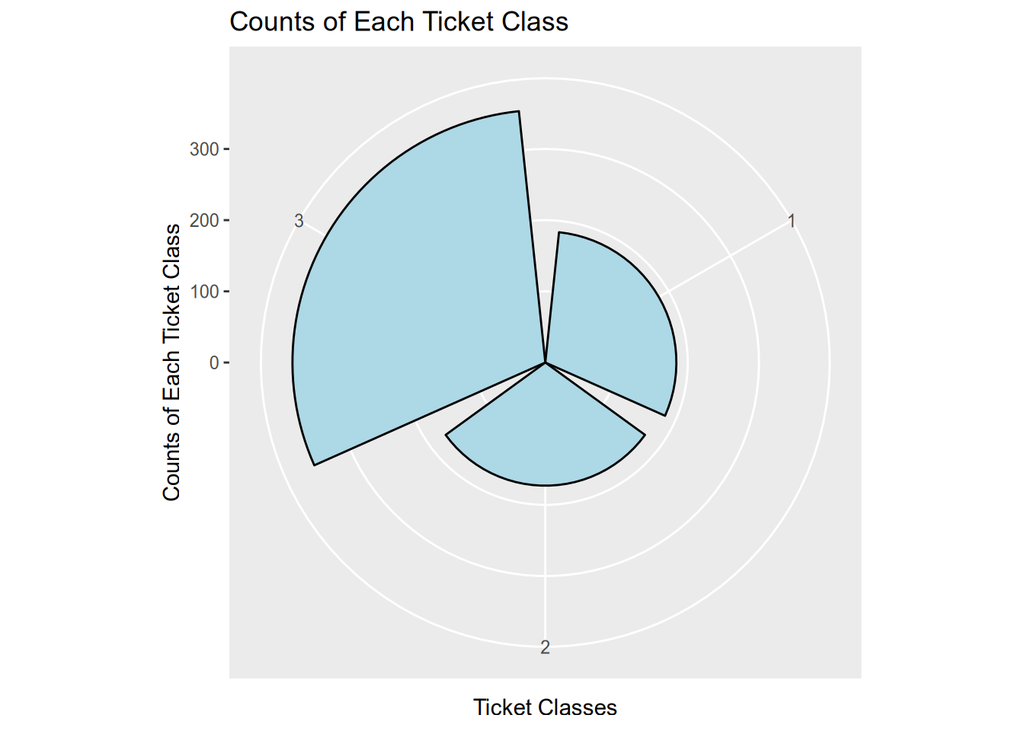

```r
ggplot(titanic, aes(x = Pclass)) +
    geom_bar(fill = "lightblue", color = "black") +
    coord_polar() +
    labs(title = "Counts of Each Ticket Class",
         fill = "Ticket Class",
         x = "Ticket Classes",
         y = "Counts of Each Ticket Class")
```

2. (3 points) In a rose diagram, what is the radius of each rose petal proportional to? What does the angle associated with each rose petal correspond to (if anything)? What is the area of each rose petal proportaional to?

The radius of each petal is proportional to the the counts of each ticket class. The angle is the same across all petals, in that it is not associated with anything in particular. The area is proportional to the square of the counts of each ticket class.

# Problem 6

**Pie Charts**:

1. (4 points) Re-create the graph from Problem 3, but use a pie chart. Be sure to correctly label the axes, if necessary. Include an appropriate title.

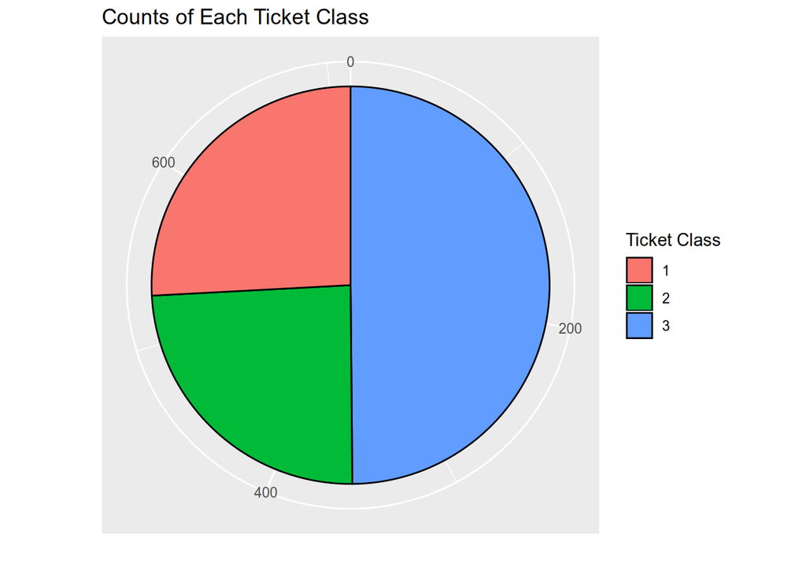

```r
ggplot(titanic, aes(x = Pclass)) +
    geom_bar(aes(x = factor(1), fill = Pclass), color = "black", width = 1) +
    coord_polar(theta = "y") +
    labs(title = "Counts of Each Ticket Class",
         fill = "Ticket Class",
         x = "", y = "") +
    theme(axis.ticks.y = element_blank(),
          axis.text.y = element_blank())
```

2. (3 points) In a pie chart, what does the radius of each pie slice correspond to (if anything)? What does the angle associated with each pie slice correspond to (if anything)?

The radius does not correspond to anything. The angle corresponds to the respective counts of each ticket class as a proportion of the total count.

3. (3 points) Summarize the differences between a rose diagram and a pie chart in no more than two sentences.

A rose diagram shows the quantities in terms of the radius while a pie chart shows the quantities in terms of the angle.

4. (10 points) Of the four graphs we used to visualize the `Pclass` variable, which do you prefer? Why? Discuss the strengths (if any) and weaknesses (if any) of each.

I prefer the bar charts as it is the simplest to intepret the numerical counts and visually compare the relative counts.  
The spine chart could be better for data with more dimensions as it could be combined with a bar chart, however it makes it hard to know the approximate numerical counts.  
The rose petal chart makes it hard to compare relative counts for counts that are close as it is harder to see the differences in the relative radii, and similarly makes it hard to see the approximate numerical counts as we have to trace the arcs to the vertical points. The pie chart has similar problems as the rose petal chart, in that it is hard to detect close differences in the angle. We are also not able to know the approximate numerical counts.

# Problem 7

**Statistical Tests**:

(5 points) What kind of statistical test could you use to show that the passengers are not equally likely to belong to any of the three classes? (think back to your earlier statistics classes)

A chi-square test of independence, where the null hypothesis is that the three classes are independent and the alternative is that the three classes are dependent.

(BONUS: 2 points) What statistical test would you use to answer the question whether a passenger’s class was associated with a passenger’s survival rate?

A chi-square test of independence, where the null hypothesis is that the survival rates are independent across classes and the alternative is that the three survival rates are dependent on the class.

# Problem 8

(3 points each)

1. Recreate the plot from Problem 3, but this time, facet on the `Embarked` variable. To do this, add `+ facet_wrap(~ facetting_variable)` to the existing line of code.

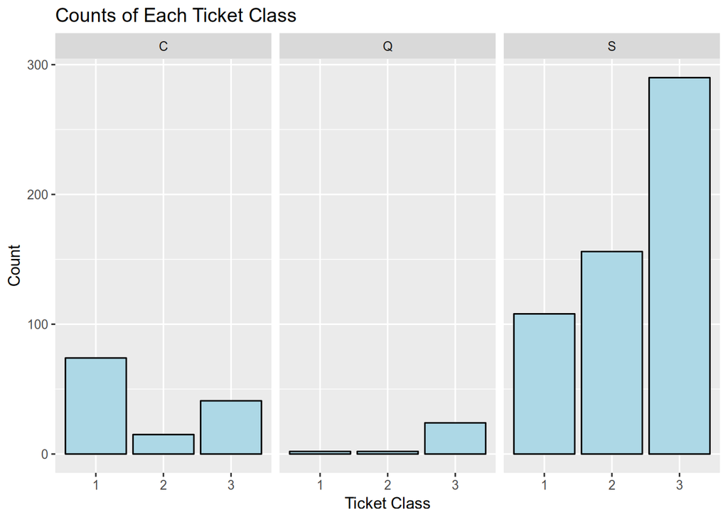

```r
ggplot(titanic, aes(x = Pclass)) +
    facet_wrap(~ Embarked) +
    geom_bar(fill = "lightblue", color = "black") +
    labs(title = "Counts of Each Ticket Class",
         x = "Ticket Class",
         y = "Count")
```

2. Adjust the `ncol` or `nrow` arguments in `facet_wrap()`. How do they affect the way `facet_wrap()` places each facet into a grid of graphs?

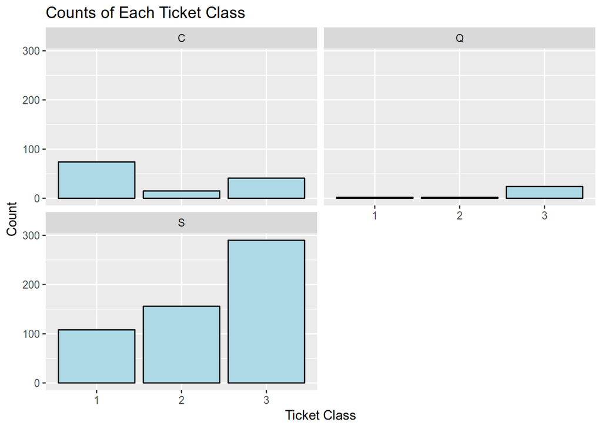

```r
ggplot(titanic, aes(x = Pclass)) +
    facet_wrap(~ Embarked, ncol = 2, nrow = 2) +
    geom_bar(fill = "lightblue", color = "black") +
    labs(title = "Counts of Each Ticket Class",
         x = "Ticket Class",
         y = "Count")
```

Adjusting `ncol` and `nrow` sets the overall grid dimensions for the graphs.

3. Sometimes, it improves our abiliity to compare across graphics if we have all the graphs in a single row or column, rather than having the plots displayed in multiple rows and columns. Recreate the plot from Problem 3, but this time, facet on the `Parch` variable using the `facet_grid()` function. To do this, add `+ facet_grid(~ facetting_variable)` to the existing line of code.

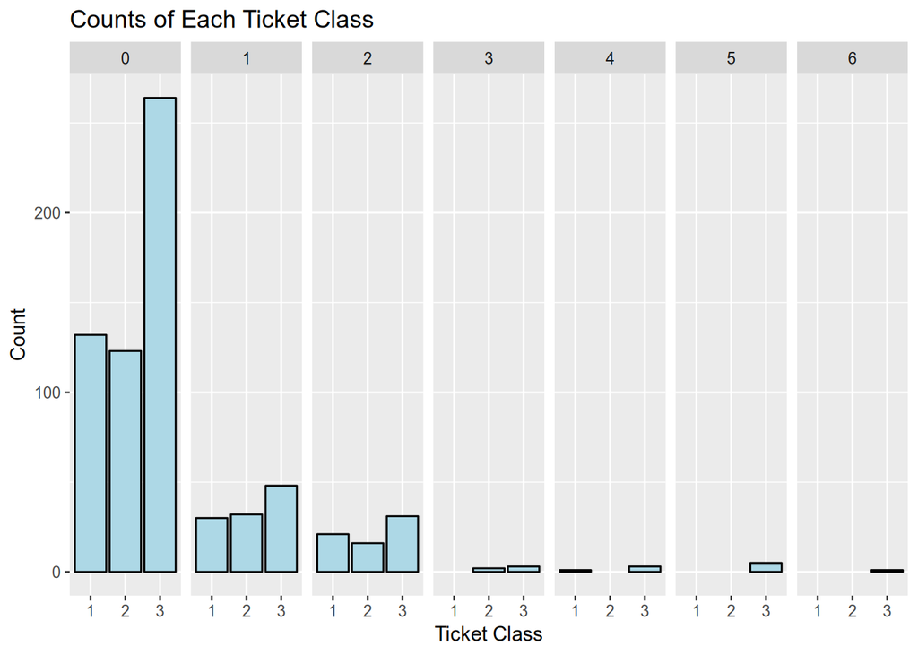

```r
ggplot(titanic, aes(x = Pclass)) +
    facet_grid(~ Parch) +
    geom_bar(fill = "lightblue", color = "black") +
    labs(title = "Counts of Each Ticket Class",
         x = "Ticket Class",
         y = "Count")
```

4. Recreate the graph from part (c), but this time, add `+ facet_grid(facetting_variable ~ .)` instead. What changed? Which version do you prefer for this particular problem? Why?

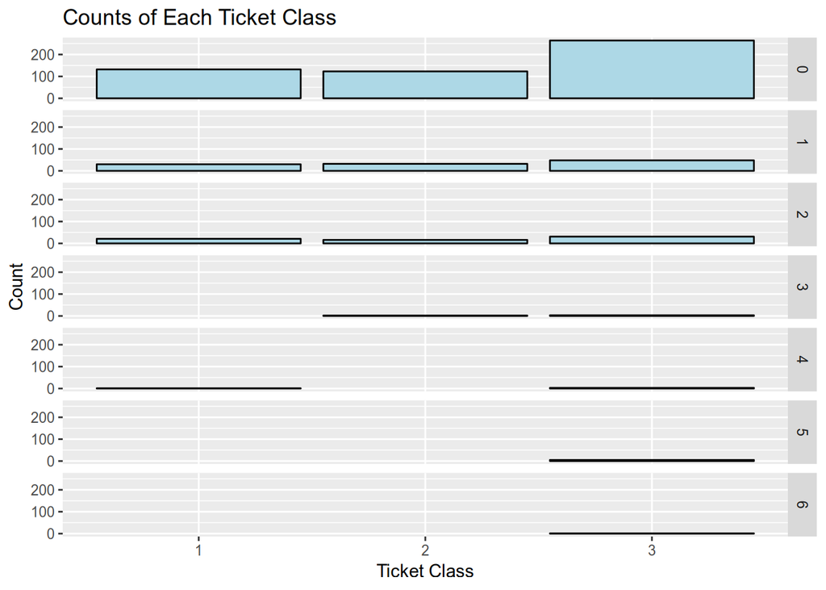

```r
ggplot(titanic, aes(x = Pclass)) +
    facet_grid(Parch ~ .) +
    geom_bar(fill = "lightblue", color = "black") +
    labs(title = "Counts of Each Ticket Class",
         x = "Ticket Class",
         y = "Count")
```

I prefer the version from part c), as the heights of each bar do not get squashed too much such that we can no longer see the trend as in this graph.

5. We can actually facet on multiple categorical variables at once. Let’s try it. Recreate the graph from part (d), but this time, facet on both the `Sex` and `Survived` variables. To do this, add `+ facet_grid(Sex ~ Survived)`. Interpret the graph. **Although in your answer please don’t wildly speculate, I encourage you to ask yourself “What is going on here?” and try to relate the graph to your knowledge about the Titanic (this will help prepare you for later in the class).**

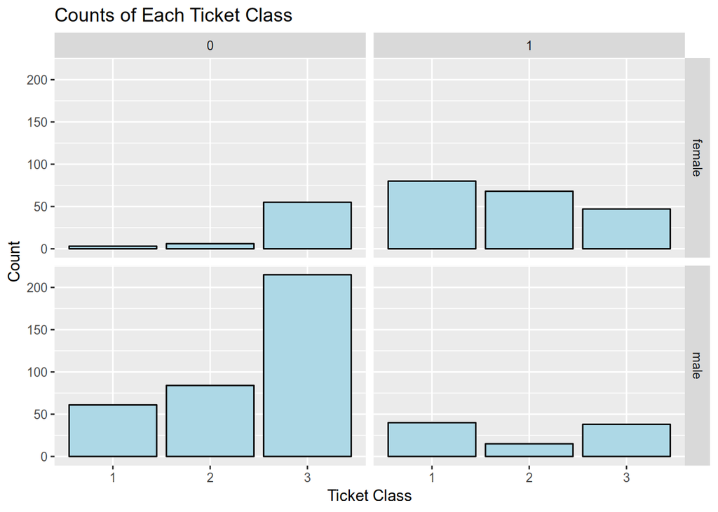

```r
ggplot(titanic, aes(x = Pclass)) +
    facet_grid(Sex ~ Survived) +
    geom_bar(fill = "lightblue", color = "black") +
    labs(title = "Counts of Each Ticket Class",
         x = "Ticket Class",
         y = "Count")
```

The females had a higher survival rate than the males, which makes sense as the females and children got off the boat first, followed by the males.

6. Repeat the facetting but this time use `Sex` and `Parch`. Some of the facets in the graph are empty. Why? (Hint: Look at a contingency table of these two variables with `table(titanic$Parch, titanic$Sex)`.) Briefly interpret graph.

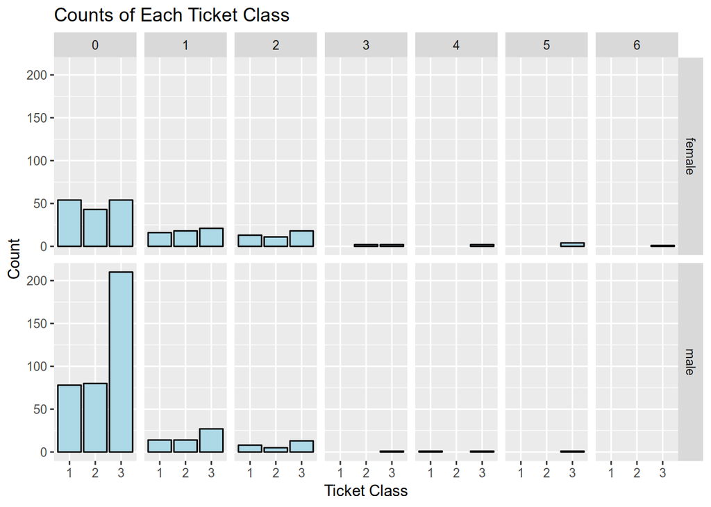

```r
ggplot(titanic, aes(x = Pclass)) +
    facet_grid(Sex ~ Parch) +
    geom_bar(fill = "lightblue", color = "black") +
    labs(title = "Counts of Each Ticket Class",
         x = "Ticket Class",
         y = "Count")
```

Some facets are empty as there are no rows in the data with those facet values, like males with 6 parents / children onboard.  
From the graph, we can see that most of the passengers on the Titanic were males with no parents or children onboard, and of these males most of them were in the 3rd ticket class.  
We can also see that in general, the number of passengers gets less as we look at increasing numbers of parents or children on board.